# Data wrangling - reptiles

# Inland sands

Next unit: the inland sands. Some exploration first:

```r
reptiles[unit %like% 'Inland' & !is.na(SciName), .(total.abnd = sum(count_individuals), total.sp.rich = uniqueN(SciName))] # 594 reptiles from 17 species
```

```
##    total.abnd total.sp.rich
##         <num>         <int>
## 1:        594            17
```

```r
alpha.div[, sort(unique(unit))]
```

```
## [1] Coastal Plain Sands
## [2] Inland Sands
## [3] Loess Covered Areas in the Northern Negev
## [4] Mediterranean-Desert Transition Zone
## [5] Planted Conifer Forests
## 5 Levels: Coastal Plain Sands ... Planted Conifer Forests
```

```r
inland.sands <- alpha.div[unit == 'Inland Sands'] # subset the inland sands
str(inland.sands)
```

```
## Classes 'data.table' and 'data.frame':   72 obs. of  23 variables:
##  $ unit               : Factor w/ 5 levels "Coastal Plain Sands",..: 2 2 2 2 2 2 2 2 2 2 ...
##  $ year               : num  2017 2017 2017 2017 2017 ...
##  $ campaign           : Factor w/ 5 levels "T0","T1","T2",..: 3 3 3 3 3 3 3 3 3 3 ...
##  $ subunit            : Factor w/ 3 levels "Carmel","Galilee",..: NA NA NA NA NA NA NA NA NA NA ...
##  $ site               : Factor w/ 35 levels "Aderet","Amatzia",..: 6 6 6 6 6 6 6 6 6 6 ...
##  $ point_name         : Factor w/ 281 levels "Aderet 31.67144877_34.9880248",..: 36 37 38 39 40 41 43 44 45 46 ...
##  $ survey_ID          : Factor w/ 691 levels "T0_Aderet 31.67867469_34.98154177",..: 292 293 294 295 296 297 298 299 300 301 ...
##  $ Date               : Date, format: "2017-06-14" "2017-06-26" ...
##  $ sin.dist.21.June   : num  -0.12 0.086 0.086 0.086 0.086 ...
##  $ cos.dist.21.June   : num  0.993 0.996 0.996 0.996 0.996 ...
##  $ sin.dist.noon      : num  -0.903 -0.981 -0.906 -0.95 -0.989 ...
##  $ cos.dist.noon      : num  0.431 -0.195 0.423 0.313 -0.148 ...
##  $ settlements        : Factor w/ 2 levels "Far","Near": NA NA NA NA NA NA NA NA NA NA ...
##  $ agriculture        : Factor w/ 2 levels "Far","Near": 1 1 1 1 1 1 2 2 2 2 ...
##  $ dunes              : Factor w/ 2 levels "semi-shifting",..: 1 1 1 2 2 2 1 1 1 2 ...
##  $ habitat            : Factor w/ 3 levels "bedouin agriculture",..: NA NA NA NA NA NA NA NA NA NA ...
##  $ mean.lon           : num  34.5 34.4 34.4 34.4 34.4 ...
##  $ mean.lat           : num  30.9 31 30.9 30.9 31 ...
##  $ species.richness   : num  4 6 6 7 6 5 8 3 6 5 ...
##  $ total.abundance    : num  10 6 15 12 10 6 8 8 10 6 ...
##  $ geom.mean.abundance: num  1.63 1 1.78 1.47 1.52 ...
##  $ year.count         : num  0 0 0 0 0 0 0 0 0 0 ...
##  $ year.fct           : Factor w/ 8 levels "2014","2015",..: 3 3 3 3 3 3 3 3 3 3 ...
##  - attr(*, "sorted")= chr "unit"
##  - attr(*, ".internal.selfref")=<externalptr>
```

```r
inland.sands[is.na(agriculture) | is.na(dunes)] # no missing variables
```

```
## Key: <unit>
## Empty data.table (0 rows and 23 cols): unit,year,campaign,subunit,site,point_name...
```

```r
inland.sands[, .(no.of.surveys = uniqueN(survey_ID)), keyby = .(campaign, year, site, agriculture, dunes)] # Always 3 surveys per site-agri-dunes
```

```
## Key: <campaign, year, site, agriculture, dunes>
##     campaign  year        site agriculture         dunes no.of.surveys
##       <fctr> <num>      <fctr>      <fctr>        <fctr>         <int>
##  1:       T2  2017  Beer Milka         Far semi-shifting             3
##  2:       T2  2017  Beer Milka         Far      shifting             3
##  3:       T2  2017  Beer Milka        Near semi-shifting             3
##  4:       T2  2017  Beer Milka        Near      shifting             3
##  5:       T2  2017      Secher         Far semi-shifting             3
##  6:       T2  2017      Secher         Far      shifting             3
##  7:       T2  2017 Shunra East         Far semi-shifting             3
##  8:       T2  2017 Shunra East         Far      shifting             3
##  9:       T3  2019  Beer Milka         Far semi-shifting             3
## 10:       T3  2019  Beer Milka         Far      shifting             3
## 11:       T3  2019  Beer Milka        Near semi-shifting             3
## 12:       T3  2019  Beer Milka        Near      shifting             3
## 13:       T3  2019      Secher         Far semi-shifting             3
## 14:       T3  2019      Secher         Far      shifting             3
## 15:       T3  2019 Shunra East         Far semi-shifting             3
## 16:       T3  2019 Shunra East         Far      shifting             3
## 17:       T4  2021  Beer Milka         Far semi-shifting             3
## 18:       T4  2021  Beer Milka         Far      shifting             3
## 19:       T4  2021  Beer Milka        Near semi-shifting             3
## 20:       T4  2021  Beer Milka        Near      shifting             3
## 21:       T4  2021      Secher         Far semi-shifting             3
## 22:       T4  2021      Secher         Far      shifting             3
## 23:       T4  2021 Shunra East         Far semi-shifting             3
## 24:       T4  2021 Shunra East         Far      shifting             3
##     campaign  year        site agriculture         dunes no.of.surveys
##       <fctr> <num>      <fctr>      <fctr>        <fctr>         <int>
```

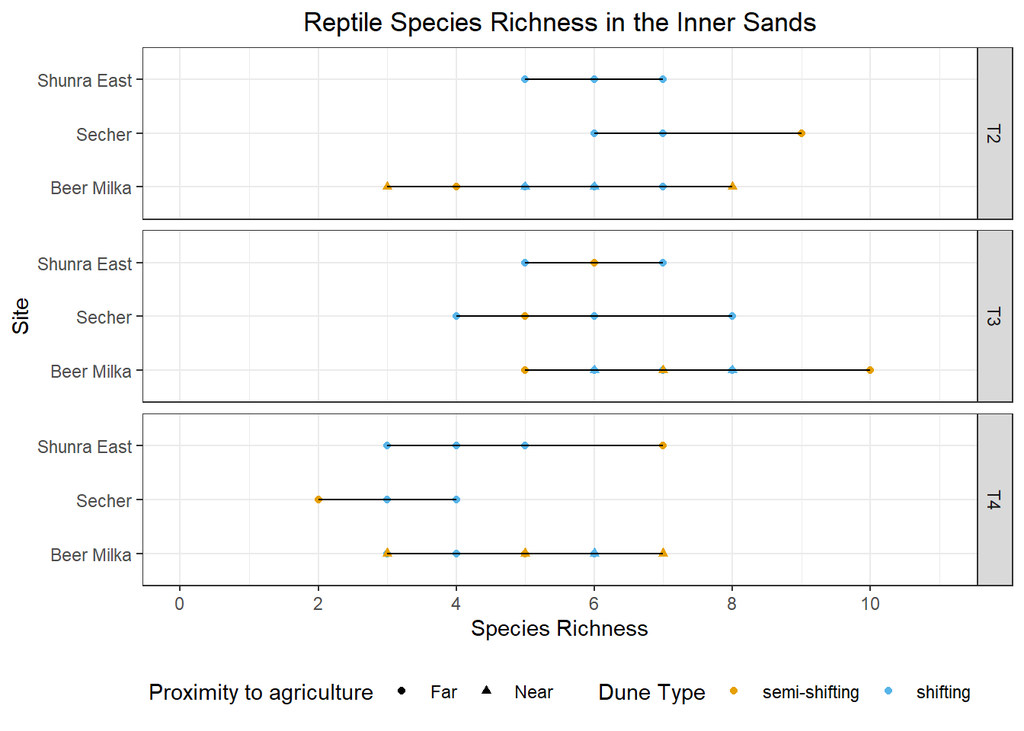

```r
# Dot plots
Inner.sands.sp.rich.dotplot <- ggplot(data = inland.sands, aes(x = species.richness, y = site)) +
  geom_point(aes(color = dunes, shape = agriculture)) +  geom_line(aes(group = site)) +
  facet_grid(campaign ~ .) + labs(title = 'Reptile Species Richness in the Inner Sands', y = 'Site', x = 'Species Richness', color = 'Dune Type',
                                  shape = 'Proximity to agriculture') +
  scale_color_manual(values = okabe) + scale_x_continuous(limits = c(0, inland.sands[, max(species.richness) + 1]),
                                                          breaks = seq(0, inland.sands[, max(species.richness) + 1], by = 2)) +
  theme_bw() + theme(legend.position = 'bottom',
                     plot.title = element_text(hjust = 0.5), plot.subtitle = element_text(hjust = 0.5))
Inner.sands.sp.rich.dotplot
```

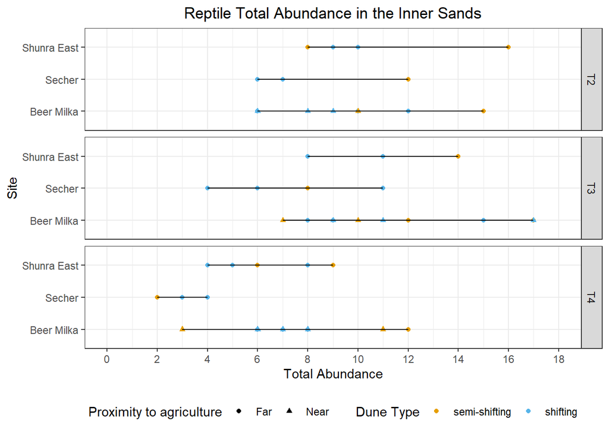

```r
ggsave(here('Figures/Reptile species richness in the Inner sands - dotplot.png'), plot = Inner.sands.sp.rich.dotplot)
Inner.sands.abnd.dotplot <- ggplot(data = inland.sands, aes(x = total.abundance, y = site)) +
  geom_point(aes(color = dunes, shape = agriculture)) +  geom_line(aes(group = site)) +
  facet_grid(campaign ~ .) + labs(title = 'Reptile Total Abundance in the Inner Sands', y = 'Site', x = 'Total Abundance', color = 'Dune Type',
                                  shape = 'Proximity to agriculture') +
  scale_color_manual(values = okabe) + scale_x_continuous(limits = c(0, inland.sands[, max(total.abundance) + 1]),
                                                          breaks = seq(0, inland.sands[, max(total.abundance) + 1], by = 2)) +
  theme_bw() + theme(legend.position = 'bottom',
                     plot.title = element_text(hjust = 0.5), plot.subtitle = element_text(hjust = 0.5))
Inner.sands.abnd.dotplot
```

```r
ggsave(here('Figures/Reptile Total Abundance in the Inner sands - dotplot.png'), plot = Inner.sands.abnd.dotplot)
```

## Inland Sands: Calculate distance to the nearest agricultural plot

First, let’s find out where are the agricultural plots:

```r
land.use.legend
```

```
## # A tibble: 12 x 3
##    Value Category           SubCategory
##    <dbl> <chr>              <chr>
##  1    11 Built-Up           Built up and road surface
##  2    12 Agriculture        Agricultural buildings
##  3    21 Disturbed          Area enclosed between roads that is less than 100,0~
##  4    22 Disturbed          Quarries and tailings
##  5    23 Disturbed          Other disturbed
##  6    25 Disturbed          Solar farms
##  7    30 Natural and Wooded Natural
##  8    35 Natural and Wooded Wooded
##  9    41 Agriculture        Cropland
## 10    42 Agriculture        Plantations and orchards
## 11    51 Water              Natural water surface
## 12    52 Water              Artificial water surface
```

It seems that the agriculture land uses are coded as 12, 41 and 42, so let’s subset those:

```r
agri.rast <- subst(land.use, c(12, 41, 42), 1, others = NA)
```

```
## |---------|---------|---------|---------|=========================================
```

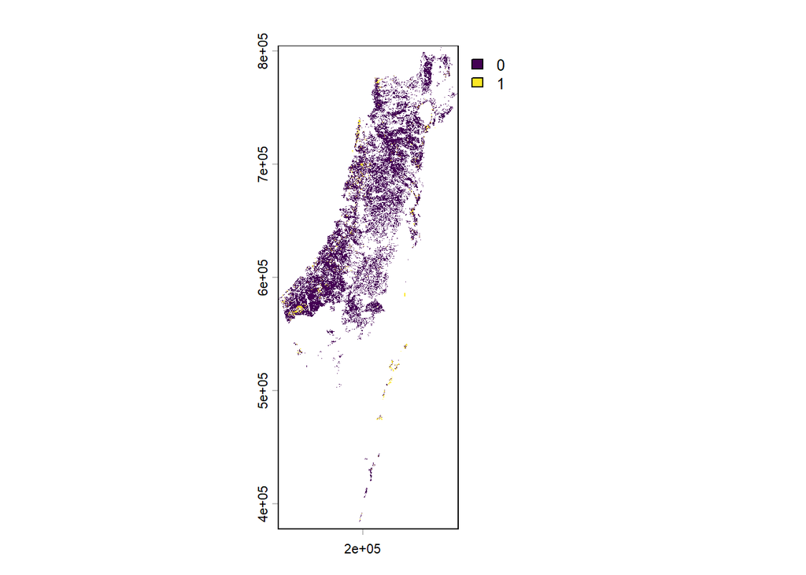

```r
plot(agri.rast) # Seems ok
```

Calculate a raster of distance to nearest agricultural cell:

```r
agri.dist <- distance(agri.rast)
```

```
## |---------|---------|---------|---------|=========================================
```

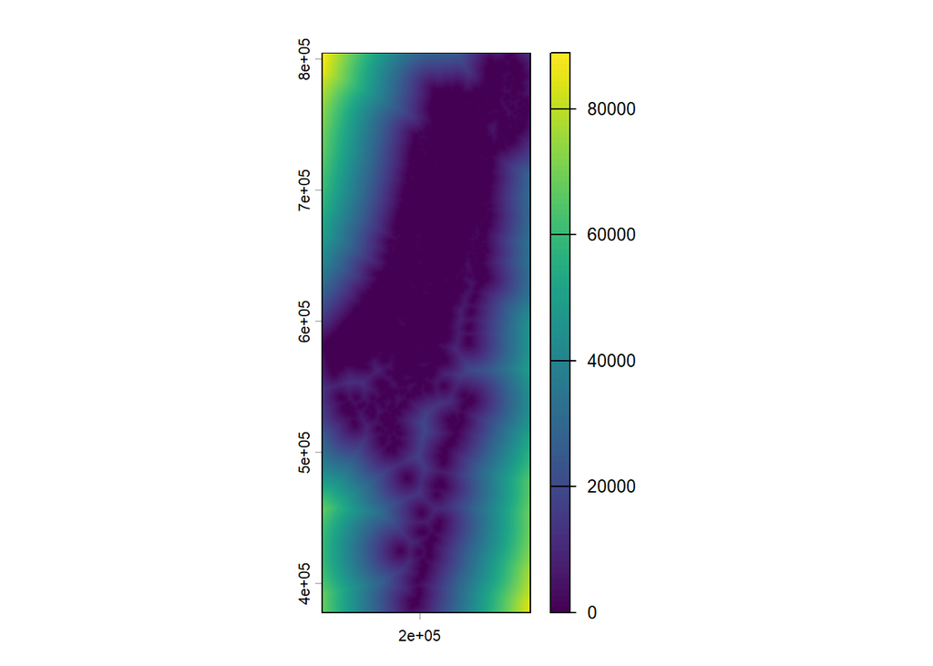

```r
plot(agri.dist) # This is more or less reasonable
```

```r
agri.dist
```

```
## class       : SpatRaster
## size        : 17052, 6343, 1  (nrow, ncol, nlyr)
## resolution  : 25, 25  (x, y)
## extent      : 125500, 284075, 378125, 804425  (xmin, xmax, ymin, ymax)
## coord. ref. : Israel 1993 / Israeli TM Grid (EPSG:2039)
## source      : spat_17e05b34229b_6112_zxzxx9jyyx6UnnI.tif
## name        : LC_Madad_MigvanB_21v1
## min value   :                  0.00
## max value   :              89104.05
```

Find the coordinates of each plot

```r
inland.sands.plots <- inland.sands[, .(lon = mean(mean.lon), lat = mean(mean.lat)), keyby = .(agriculture, point_name)] # Find the unique coordinates per plot
inland.sands.plots[, .N, keyby = point_name][N > 1] # sanity check: Should yield an empty data.table
```

```
## Key: <point_name>
## Empty data.table (0 rows and 2 cols): point_name,N
```

```r
inland.sands.plots <- st_as_sf(inland.sands.plots, coords = c("lon", "lat"), crs = 4326, remove = F) %>% st_transform(crs = 2039) # Convert to sf and reproject as Israel Transeverse Meractor
as.data.table(inland.sands.plots)
```

```
##     agriculture                      point_name      lon      lat
##          <fctr>                          <fctr>    <num>    <num>
##  1:         Far  Beer Milka Far Semi-Shifting 2 34.45425 30.92433
##  2:         Far  Beer Milka Far Semi-Shifting 3 34.38646 30.98195
##  3:         Far  Beer Milka Far Semi-Shifting 4 34.41959 30.94558
##  4:         Far       Beer Milka Far Shifting 1 34.41844 30.94737
##  5:         Far       Beer Milka Far Shifting 2 34.37756 30.98177
##  6:         Far       Beer Milka Far Shifting 3 34.44647 30.91561
##  7:         Far      Beer Milka Far Shifting 3a 34.44179 30.91634
##  8:         Far      Secher Far Semi-Shifting 1 34.76438 31.08343
##  9:         Far      Secher Far Semi-Shifting 3 34.77875 31.10025
## 10:         Far      Secher Far Semi-Shifting 4 34.77846 31.10849
## 11:         Far           Secher Far Shifting 1 34.77744 31.10155
## 12:         Far           Secher Far Shifting 2 34.77956 31.10864
## 13:         Far           Secher Far Shifting 3 34.77427 31.08919
```

[output cut: 43 more lines]

Now let’s extract the distances of each plot to the nearest agricultural cell:

```r
inland.sands.plots <- as.data.table(cbind(inland.sands.plots, extract(agri.dist, vect(inland.sands.plots))))
inland.sands.plots # Seems reasonable
```

```
##     agriculture                      point_name      lon      lat    ID
##          <fctr>                          <fctr>    <num>    <num> <num>
##  1:         Far  Beer Milka Far Semi-Shifting 2 34.45425 30.92433     1
##  2:         Far  Beer Milka Far Semi-Shifting 3 34.38646 30.98195     2
##  3:         Far  Beer Milka Far Semi-Shifting 4 34.41959 30.94558     3
##  4:         Far       Beer Milka Far Shifting 1 34.41844 30.94737     4
##  5:         Far       Beer Milka Far Shifting 2 34.37756 30.98177     5
##  6:         Far       Beer Milka Far Shifting 3 34.44647 30.91561     6
##  7:         Far      Beer Milka Far Shifting 3a 34.44179 30.91634     7
##  8:         Far      Secher Far Semi-Shifting 1 34.76438 31.08343     8
##  9:         Far      Secher Far Semi-Shifting 3 34.77875 31.10025     9
## 10:         Far      Secher Far Semi-Shifting 4 34.77846 31.10849    10
## 11:         Far           Secher Far Shifting 1 34.77744 31.10155    11
## 12:         Far           Secher Far Shifting 2 34.77956 31.10864    12
## 13:         Far           Secher Far Shifting 3 34.77427 31.08919    13
```

[output cut: 43 more lines]

Summarize and export the results:

```r
inland.sands.plots[, .(mean.dist.to.agr = mean(LC_Madad_MigvanB_21v1), min.dist.to.agr = min(LC_Madad_MigvanB_21v1), max.dist.to.agr = max(LC_Madad_MigvanB_21v1), N = uniqueN(point_name)), keyby = agriculture]
```

```
## Key: <agriculture>
##    agriculture mean.dist.to.agr min.dist.to.agr max.dist.to.agr     N
##         <fctr>            <num>           <num>           <num> <int>
## 1:         Far        1972.0992       977.88037        3330.541    19
## 2:        Near         111.8277        70.71068         175.000     6
```

```r
write_excel_csv(inland.sands.plots, here("Output/Inland sands reptiles - distances to agriculture per plot.csv"))
write_excel_csv(inland.sands.plots[, .(mean.dist.to.agr = mean(LC_Madad_MigvanB_21v1), min.dist.to.agr = min(LC_Madad_MigvanB_21v1), max.dist.to.agr = max(LC_Madad_MigvanB_21v1), no.of.plots = uniqueN(point_name)), keyby = agriculture], here("Output/Inland sands reptiles - distances to agriculture summary statistics.csv"))
```

# Loess

Some data exploration:

```r
reptiles[unit %like% 'Loess' & !is.na(SciName), .(total.abnd = sum(count_individuals), total.sp.rich = uniqueN(SciName))]
```

```
##    total.abnd total.sp.rich
##         <num>         <int>
## 1:        283            23
```

```r
## Loess species richness----
loess <- alpha.div[unit == 'Loess Covered Areas in the Northern Negev']
loess[campaign == 'T0', ':=' (year = 2014, year.fct = as.factor(2014))]

str(loess)
```

```
## Classes 'data.table' and 'data.frame':   112 obs. of  23 variables:
##  $ unit               : Factor w/ 5 levels "Coastal Plain Sands",..: 3 3 3 3 3 3 3 3 3 3 ...
##  $ year               : num  2014 2014 2014 2014 2014 ...
##  $ campaign           : Factor w/ 5 levels "T0","T1","T2",..: 1 1 1 1 1 1 1 1 1 1 ...
##  $ subunit            : Factor w/ 3 levels "Carmel","Galilee",..: NA NA NA NA NA NA NA NA NA NA ...
##  $ site               : Factor w/ 35 levels "Aderet","Amatzia",..: 11 11 11 14 14 14 24 24 24 24 ...
##  $ point_name         : Factor w/ 281 levels "Aderet 31.67144877_34.9880248",..: 87 88 91 108 109 110 184 185 186 187 ...
##  $ survey_ID          : Factor w/ 691 levels "T0_Aderet 31.67867469_34.98154177",..: 40 41 42 49 50 51 88 89 90 91 ...
##  $ Date               : Date, format: "2014-06-16" "2014-06-16" ...
##  $ sin.dist.21.June   : num  -0.086 -0.086 -0.086 0.171 0.171 ...
##  $ cos.dist.21.June   : num  0.996 0.996 0.996 0.985 0.985 ...
##  $ sin.dist.noon      : num  -0.165 -0.375 -0.676 -0.375 -0.462 ...
##  $ cos.dist.noon      : num  0.986 0.927 0.737 0.927 0.887 ...
##  $ settlements        : Factor w/ 2 levels "Far","Near": NA NA NA NA NA NA NA NA NA NA ...
##  $ agriculture        : Factor w/ 2 levels "Far","Near": NA NA NA NA NA NA NA NA NA NA ...
##  $ dunes              : Factor w/ 2 levels "semi-shifting",..: NA NA NA NA NA NA NA NA NA NA ...
##  $ habitat            : Factor w/ 3 levels "bedouin agriculture",..: 1 1 1 1 1 1 1 1 1 2 ...
##  $ mean.lon           : num  34.7 34.7 NaN 34.8 34.8 ...
##  $ mean.lat           : num  31.3 31.3 NaN 31.4 31.4 ...
##  $ species.richness   : num  2 1 0 1 2 1 2 1 1 0 ...
##  $ total.abundance    : num  6 3 0 4 7 4 6 2 5 0 ...
##  $ geom.mean.abundance: num  2.24 3 0 4 2.45 ...
##  $ year.count         : num  0 0 0 0 0 0 0 0 0 0 ...
##  $ year.fct           : Factor w/ 8 levels "2014","2015",..: 1 1 1 1 1 1 1 1 1 1 ...
##  - attr(*, "sorted")= chr "unit"
##  - attr(*, ".internal.selfref")=<externalptr>
```

```r
loess[is.na(habitat)] # no missing variables
```

```
## Key: <unit>
## Empty data.table (0 rows and 23 cols): unit,year,campaign,subunit,site,point_name...
```

```r
loess[, sort(unique(year)), keyby = campaign] # 2014-2020 every 2 years
```

```
## Key: <campaign>
##    campaign    V1
##      <fctr> <num>
## 1:       T0  2014
## 2:       T1  2016
## 3:       T2  2018
## 4:       T3  2020
```

```r
loess[, .(no.of.sites = uniqueN(site)), keyby = .(campaign, year)]
```

```
## Key: <campaign, year>
##    campaign  year no.of.sites
##      <fctr> <num>       <int>
## 1:       T0  2014           6
## 2:       T1  2016           7
## 3:       T2  2018           7
## 4:       T3  2020           7
```

```r
loess[, .(no.of.surveys = uniqueN(survey_ID)), keyby = .(campaign, year, site)]
```

```
## Key: <campaign, year, site>
##     campaign  year            site no.of.surveys
##       <fctr> <num>          <fctr>         <int>
##  1:       T0  2014    Eshel Hanasi             3
##  2:       T0  2014       Givot Bar             3
##  3:       T0  2014 Mishmar Hanegev             6
##  4:       T0  2014     Nahal Ashan             6
##  5:       T0  2014      Park Loess             3
##  6:       T0  2014  Sayeret Shaked             6
##  7:       T1  2016    Eshel Hanasi             3
##  8:       T1  2016       Givot Bar             3
##  9:       T1  2016           Goral             3
## 10:       T1  2016 Mishmar Hanegev             6
## 11:       T1  2016     Nahal Ashan             6
## 12:       T1  2016      Park Loess             3
```

[output cut: 17 more lines]

```r
loess[, .(no.of.surveys = uniqueN(survey_ID)), keyby = .(campaign, year, site, habitat)]
```

```
## Key: <campaign, year, site, habitat>
##     campaign  year            site             habitat no.of.surveys
##       <fctr> <num>          <fctr>              <fctr>         <int>
##  1:       T0  2014    Eshel Hanasi bedouin agriculture             3
##  2:       T0  2014       Givot Bar bedouin agriculture             3
##  3:       T0  2014 Mishmar Hanegev bedouin agriculture             3
##  4:       T0  2014 Mishmar Hanegev       kkl plantings             3
##  5:       T0  2014     Nahal Ashan       kkl plantings             3
##  6:       T0  2014     Nahal Ashan               loess             3
##  7:       T0  2014      Park Loess               loess             3
##  8:       T0  2014  Sayeret Shaked       kkl plantings             3
##  9:       T0  2014  Sayeret Shaked               loess             3
## 10:       T1  2016    Eshel Hanasi bedouin agriculture             3
## 11:       T1  2016       Givot Bar bedouin agriculture             3
## 12:       T1  2016           Goral bedouin agriculture             3
```

[output cut: 29 more lines]

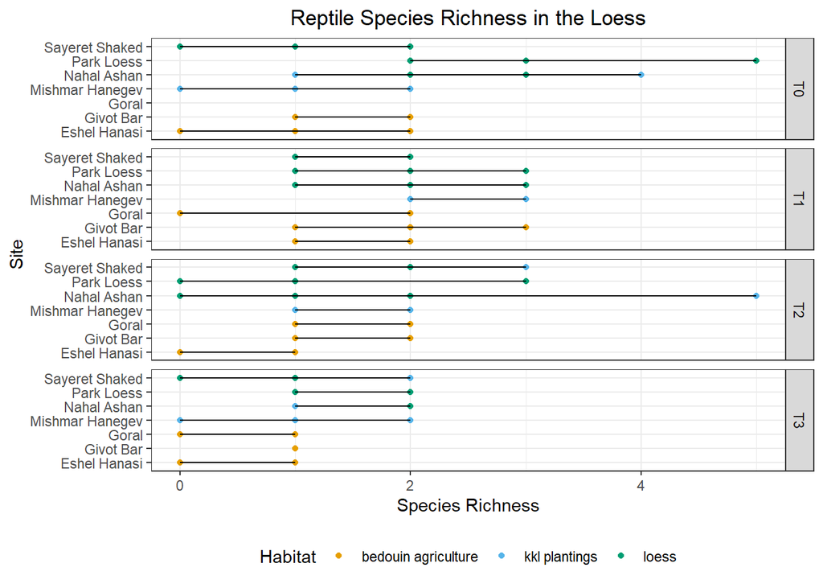

```r
# The relevant predictors are habitat and temporal trend

# Dot plots
loess.sp.rich.dotplot <- ggplot(data = loess, aes(x = species.richness, y = site)) +
  geom_point(aes(color = habitat)) +  geom_line(aes(group = site)) +
  facet_grid(campaign ~ .) + labs(title = 'Reptile Species Richness in the Loess', y = 'Site', x = 'Species Richness', color = 'Habitat') +
  scale_color_manual(values = okabe) + scale_x_continuous(limits = c(0, loess[, max(species.richness)]),
                                                          breaks = seq(0, loess[, max(species.richness)], by = 2)) +
  theme_bw() + theme(legend.position = 'bottom',
                     plot.title = element_text(hjust = 0.5), plot.subtitle = element_text(hjust = 0.5))
loess.sp.rich.dotplot
```

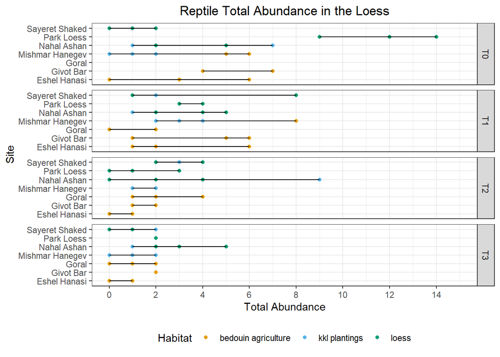

```r
ggsave(here('Figures/Reptile species richness in the Loess - dotplot.png'), plot = loess.sp.rich.dotplot)
loess.abnd.dotplot <- ggplot(data = loess, aes(x = total.abundance, y = site)) +
  geom_point(aes(color = habitat)) +  geom_line(aes(group = site)) +
  facet_grid(campaign ~ .) + labs(title = 'Reptile Total Abundance in the Loess', y = 'Site', x = 'Total Abundance', color = 'Habitat') +
  scale_color_manual(values = okabe) + scale_x_continuous(limits = c(0, loess[, max(total.abundance) + 1]),
                                                          breaks = seq(0, loess[, max(total.abundance) + 1], by = 2)) +
  theme_bw() + theme(legend.position = 'bottom',
                     plot.title = element_text(hjust = 0.5), plot.subtitle = element_text(hjust = 0.5))
loess.abnd.dotplot
```

```r
ggsave(here('Figures/Reptile Total Abundance in the Loess - dotplot.png'), plot = loess.abnd.dotplot)
```

## Planted Conifer Forest

We want to calculate the distance to nearest army base or settlement. For that, we need to create a unified object of both settlements and army bases. To do that, we need to use the function `rbind` on these sf objects, if they have the same columns. First, let’s see what columns (attributes) each sf object has:

```r
str(army.bases)
```

```
## Classes 'sf' and 'data.frame':   296 obs. of  7 variables:
##  $ Name      : chr  "Ein Shemer" NA NA "Orot Rabin" ...
##  $ Descriptio: chr  "description: Base<br>Name_Code: MK 81" "description: <br>Name_Code:" "description: <br>Name_Code:" "description: Infrastructure<br>Name_Code:" ...
##  $ ID_Code   : chr  NA NA NA NA ...
##  $ Use       : chr  NA NA NA NA ...
##  $ Establish : chr  NA NA NA NA ...
##  $ Evacuation: chr  NA NA NA NA ...
##  $ geometry  :sfc_POLYGON of length 296; first list element: List of 1
##   ..$ : num [1:66, 1:3] 35 35 35 35 35 ...
##   ..- attr(*, "class")= chr [1:3] "XYZ" "POLYGON" "sfg"
##  - attr(*, "sf_column")= chr "geometry"
##  - attr(*, "agr")= Factor w/ 3 levels "constant","aggregate",..: NA NA NA NA NA NA
##   ..- attr(*, "names")= chr [1:6] "Name" "Descriptio" "ID_Code" "Use" ...
```

```r
str(settlements)
```

```
## Classes 'sf' and 'data.frame':   1947 obs. of  12 variables:
##  $ UNIQ_ID   : num  65973723 54454725 66198096 54453344 54454378 ...
##  $ PARENT    : num  54455173 0 64805429 0 0 ...
##  $ FCODE     : int  271 271 271 271 271 271 271 271 271 271 ...
##  $ SETL_CODE : int  478 0 997 873 0 358 1321 0 0 0 ...
##  $ SETL_NAME : chr  "איכסאל" NA "רומת אל-הייב" "שלווה" ...
##  $ SETL_NAME_: chr  "Iksal" NA "Rumat al-Hayb" "Shalva" ...
##  $ ORIG_AREA : num  2128440 263500 1312440 933307 209841 ...
##  $ DATA_YEAR : int  2018 0 2021 0 0 2018 2018 0 0 0 ...
##  $ PRDCT_VER : chr  "2019-03" NA "2021-06" NA ...
##  $ Shape_Leng: num  11768 2731 8222 4325 2535 ...
##  $ Shape_Area: num  2128440 263500 1312440 933307 209841 ...
##  $ geometry  :sfc_POLYGON of length 1947; first list element: List of 1
##   ..$ : num [1:203, 1:2] 229145 229145 229145 229145 229146 ...
##   ..- attr(*, "class")= chr [1:3] "XY" "POLYGON" "sfg"
##  - attr(*, "sf_column")= chr "geometry"
##  - attr(*, "agr")= Factor w/ 3 levels "constant","aggregate",..: NA NA NA NA NA NA NA NA NA NA ...
##   ..- attr(*, "names")= chr [1:11] "UNIQ_ID" "PARENT" "FCODE" "SETL_CODE" ...
```

Unite the settlements and army base objects before calculating the distance to nearest army base or settlement:

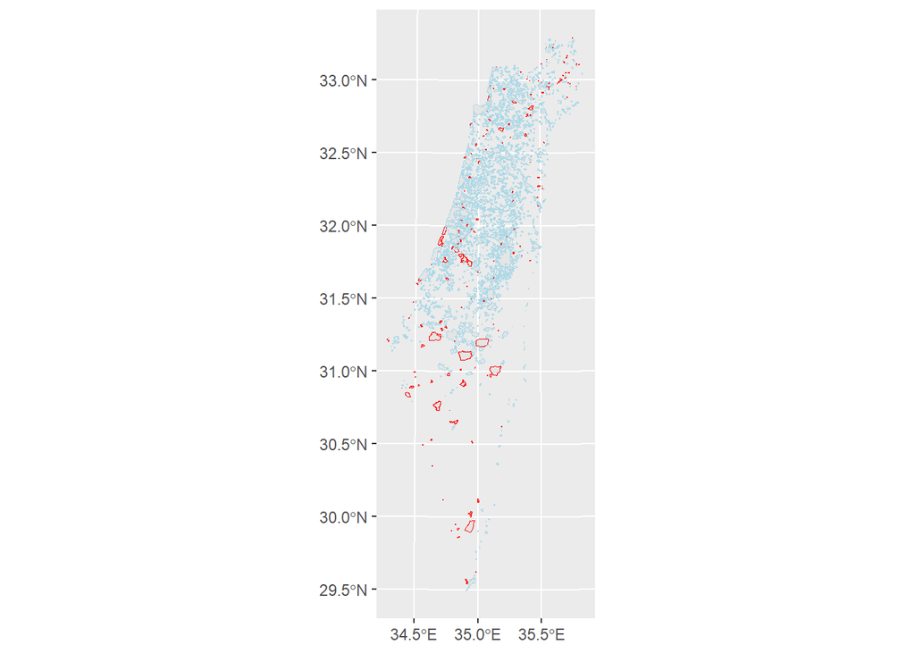

```r
army.bases <- st_transform(army.bases, crs = st_crs(settlements)) # Make sure the sf object share a coordinate reference system
army.bases <- as.data.table(army.bases)[, .(SETL_NAME = Name, type = "Security Forces Base", geometry)] %>% st_as_sf()
settlements <- as.data.table(settlements)[, .(SETL_NAME, type = "Settlement", geometry)] %>% st_as_sf()
ggplot() + geom_sf(data = army.bases, color = "red") + geom_sf(data = settlements, color = "lightblue")
```

Rasterize the army bases:

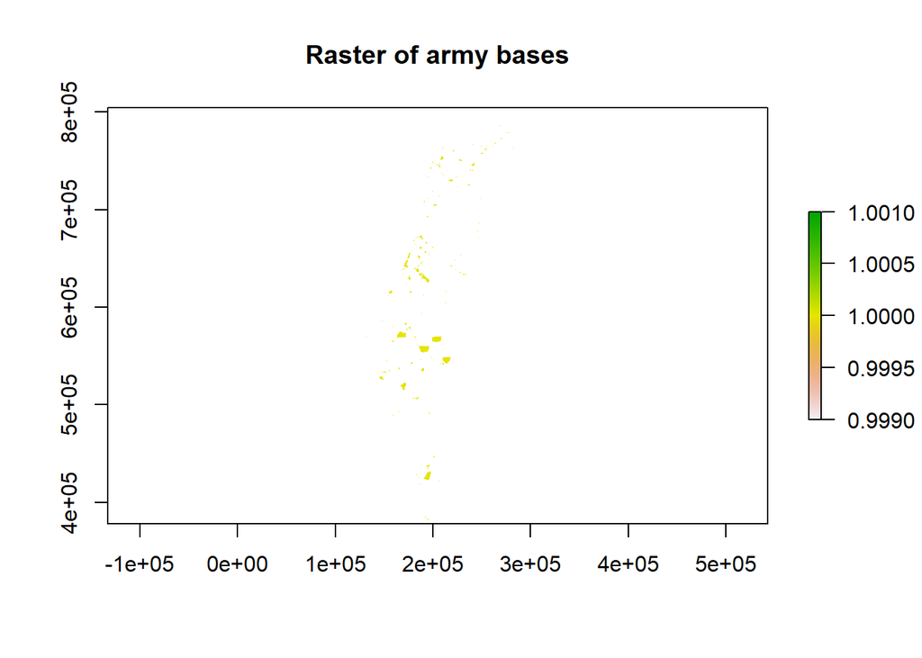

```r
base.rast <- fasterize::fasterize(army.bases, raster = raster(land.use), field = NULL)
plot(base.rast, main = "Raster of army bases") # make sure the resultig raster makes sense
```

```r
terra::writeRaster(base.rast, here("data/GIS/Army base raster.tiff"), overwrite = T) # export the raster
base.rast <- terra::rast(here("data/GIS/Army base raster.tiff")) # use terra to point to the geotiff file we just created to save memory
```

Rasterize the settlements:

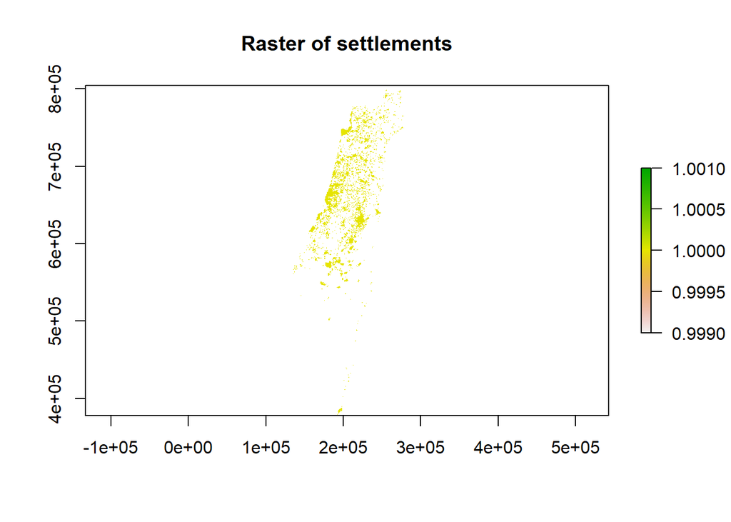

```r
sett.rast <- fasterize::fasterize(settlements, raster = raster(land.use), field = NULL)
plot(sett.rast, main = "Raster of settlements") # make sure the resulting raster makes sense
```

```r
terra::writeRaster(sett.rast, here("data/GIS/Settlement raster 2021.tiff"), overwrite = T) # export the raster
sett.rast <- terra::rast(here("data/GIS/Settlement raster 2021.tiff")) # use terra to point to the geotiff file we just created to save memory
gc() # free up memory
```

```
##            used  (Mb) gc trigger   (Mb)  max used   (Mb)
## Ncells  5621223 300.3    9023527  482.0   9023527  482.0
## Vcells 11353392  86.7  398463043 3040.1 498078803 3800.1
```

Combine the army bases and settlements rasters:

```r
sett.base.rast <- terra::mosaic(sett.rast, base.rast)
```

```
## |---------|---------|---------|---------|=========================================
```

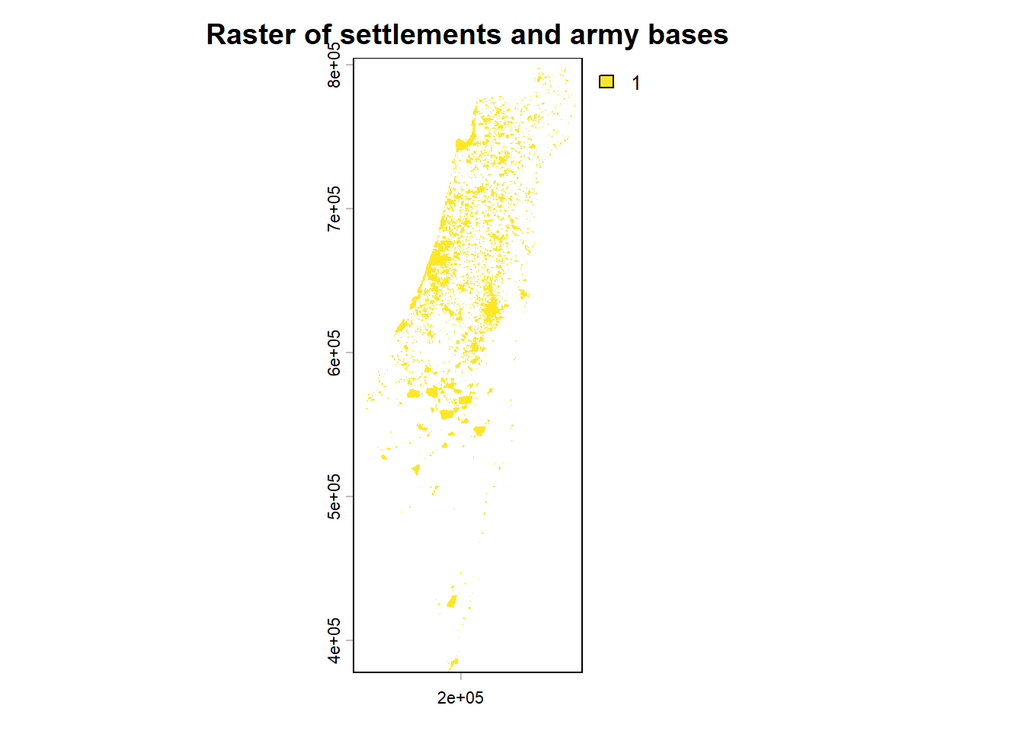

```r
plot(sett.base.rast, main = "Raster of settlements and army bases")
```

```r
terra::writeRaster(sett.base.rast, here("data/GIS/Raster of settlements and army bases.tiff"), overwrite = T) # export the resulting raster as a file
sett.base.rast <- terra::rast(here("data/GIS/Raster of settlements and army bases.tiff")) # redefine the raster based on the file we just created
gc() # free up memory
```

```
##            used  (Mb) gc trigger   (Mb)  max used   (Mb)
## Ncells  5622710 300.3    9023527  482.0   9023527  482.0
## Vcells 11357597  86.7  318770435 2432.1 498078803 3800.1
```

Distance of plots to nearest settlement or army base:

```r
sett.dist <- distance(sett.base.rast)
```

```
## |---------|---------|---------|---------|=========================================
```

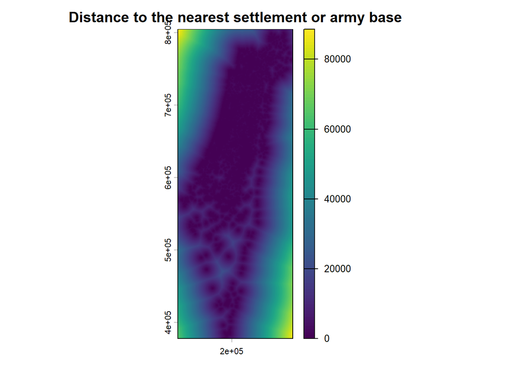

```r
plot(sett.dist, main = "Distance to the nearest settlement or army base") # This is more or less reasonable
```

```r
sett.dist
```

```
## class       : SpatRaster
## size        : 17052, 6343, 1  (nrow, ncol, nlyr)
## resolution  : 25, 25  (x, y)
## extent      : 125500, 284075, 378125, 804425  (xmin, xmax, ymin, ymax)
## coord. ref. : +proj=tmerc +lat_0=31.7343936111111 +lon_0=35.2045169444444 +k=1.0000067 +x_0=219529.584 +y_0=626907.39 +ellps=GRS80 +units=m +no_defs
## source      : spat_17e012b71017_6112_lwU2fR7NDl3n2BP.tif
## name        : Settlement raster 2021
## min value   :                   0.00
## max value   :               88807.41
```

```r
writeRaster(sett.dist, here("Output/Raster of distances to the nearest settlement or army base.tif"), overwrite = T)
```

Find the coordinates of each plot

```r
Forest.plots <- reptiles[unit %like% "Forest" & !is.na(latitude) & !is.na(longitude), .(latitude = mean(latitude), longitude = mean(longitude)), keyby = .(point_name)] # Find the unique coordinates per plot
Forest.plots[, .N, keyby = point_name][N > 1] # sanity check: Should yield an empty data.table
```

```
## Key: <point_name>
## Empty data.table (0 rows and 2 cols): point_name,N
```

```r
Forest.plots <- st_as_sf(Forest.plots, coords = c("longitude", "latitude"), crs = 4326, remove = F) %>% st_transform(crs = 2039) # Convert to sf and reproject as Israel Transverse Mercator
as.data.table(Forest.plots)
```

```
##                                 point_name latitude longitude
##                                     <fctr>    <num>     <num>
##  1:          Aderet 31.67144877_34.9880248 31.67145  34.98802
##  2:         Aderet 31.67577723_34.98668826 31.67578  34.98669
##  3:         Aderet 31.67867469_34.98154177 31.67867  34.98154
##  4:                           Aderet Kkl 2 31.67578  34.98668
##  5:                           Aderet Kkl 3 31.67145  34.98802
##  6:         Amatzia 31.50751869_34.8949584 31.50752  34.89496
##  7:        Amatzia 31.50752022_34.89495214 31.50752  34.89495
##  8:        Amatzia 31.51244719_34.89349107 31.51245  34.89349
##  9:         Amatzia 31.51244878_34.8934848 31.51245  34.89348
## 10:         Amatzia 31.51439867_34.8982574 31.51440  34.89826
## 11:        Amatzia 31.51440028_34.89825118 31.51440  34.89825
## 12:     Bat Shlomo 32.58547442_35.01415585 32.58547  35.01416
## 13:     Bat Shlomo 32.58716874_35.01054242 32.58717  35.01054
```

[output cut: 173 more lines]

```r
reptiles[unit %like% "Forest" & !point_name %in% Forest.plots$point_name, unique(point_name)]
```

```
## [1] Bat Shlomo Far 2                 Ramat Hashofet - Kkl Plantings 3
## [3] Eitanim Far 1                    Eitanim Far 3
## [5] Eshtaol Far 1                    Givat Yeshayahu Far 1
## 281 Levels: Aderet 31.67144877_34.9880248 ... Zuriel Kkl Plantings 3
```

Now let’s extract the distances of each plot to the nearest settlement or army base cell:

```r
Forest.plots <- as.data.table(cbind(Forest.plots, terra::extract(sett.dist, vect(Forest.plots))))
setnames(Forest.plots, old = "Settlement.raster.2021", new = "dist_nearest_sett") # rename for clarity
Forest.plots # Seems reasonable
```

```
##                                 point_name latitude longitude    ID
##                                     <fctr>    <num>     <num> <num>
##  1:          Aderet 31.67144877_34.9880248 31.67145  34.98802     1
##  2:         Aderet 31.67577723_34.98668826 31.67578  34.98669     2
##  3:         Aderet 31.67867469_34.98154177 31.67867  34.98154     3
##  4:                           Aderet Kkl 2 31.67578  34.98668     4
##  5:                           Aderet Kkl 3 31.67145  34.98802     5
##  6:         Amatzia 31.50751869_34.8949584 31.50752  34.89496     6
##  7:        Amatzia 31.50752022_34.89495214 31.50752  34.89495     7
##  8:        Amatzia 31.51244719_34.89349107 31.51245  34.89349     8
##  9:         Amatzia 31.51244878_34.8934848 31.51245  34.89348     9
## 10:         Amatzia 31.51439867_34.8982574 31.51440  34.89826    10
## 11:        Amatzia 31.51440028_34.89825118 31.51440  34.89825    11
## 12:     Bat Shlomo 32.58547442_35.01415585 32.58547  35.01416    12
## 13:     Bat Shlomo 32.58716874_35.01054242 32.58717  35.01054    13
```

[output cut: 173 more lines]

Summarize and export the results:

```r
Forest.plots[, .(mean.dist.to.sett = mean(dist_nearest_sett), min.dist.to.sett = min(dist_nearest_sett), max.dist.to.sett = max(dist_nearest_sett), N = uniqueN(point_name))]
```

```
##    mean.dist.to.sett min.dist.to.sett max.dist.to.sett     N
##                <num>            <num>            <num> <int>
## 1:          959.6011         235.8495         2280.351    90
```

```r
write_excel_csv(Forest.plots, here("Output/Forest reptiles - distances to settlement or army base per plot.csv"))
write_excel_csv(Forest.plots[, .(mean.dist.to.sett = mean(dist_nearest_sett), min.dist.to.sett = min(dist_nearest_sett), max.dist.to.sett = max(dist_nearest_sett), no.of.plots = uniqueN(point_name))], here("Output/Forest reptiles - distances to settlement or army base summary statistics.csv"))
```